# A quick introduction to social network analysis in R

Researcher Connect Tech-Travaganza 2021

[figure not shown]

*We acknowledge that we are on the lands of the Wurundjeri people who have been custodians of this land for thousands of years, and acknowledge and pay our respects to their Elders past and present.*

### Introduction

In this session, we will learn how to format, visualize, and interpret network data in R. After a brief introduction, we will explore a fun sample dataset together. We will then briefly discuss some exciting recent developments in the field that apply to HASS research. Our ultimate goal is to get a feel for what Social Network Analysis (SNA) is and how it works. Links to more comprehensive introductory materials will be shared with the participants at the end of the session. We will close out with a Q&A.

No previous programming experience is necessary but an inquisitive attitude towards data science is encouraged.

I also encourage you to focus primarily on the concepts covered here and worry about the programming side of things later. The R code and datasets used in this tutorial are available for further study and practice [here](https://github.com/tsquaredrx/sna-r).

### Tools

You will need to install [R](https://www.r-project.org/), [R Studio](https://www.rstudio.com/products/rstudio/) (download R Studio Desktop FREE version), and the `igraph` package (once you have the first two links installed).

### Social network analysis

Social network analysis has become a popular method for studying human behavior in the last few years, largely due to innovations in network theory and statistical modeling. Improvements in computational capability have also led to a proliferation of software that can process and analyze network data quickly. Many analytical problems can be thought of as network problems, among them friendship formation, peer influence, social inequality, career mobility, social marketing, organizational competition, economic development, political alliance, diffusion of innovations, contagion of health outcomes, and even protein interactions.

### SNA Terminology

[figure not shown]

Our made-up friendship dataset:

Nodes dataset

| name | party |
| --- | --- |
| Chris | Liberal |
| Jess | Liberal |
| Mike | Greens |
| Helen | Liberal |
| Josh | Labor |
| Wendy | Labor |
| Mohammed | Liberal |
| Leila | Greens |
| Sally | Labor |
| Rob | Labor |
| Amy | Greens |
| Justin | Labor |
| Li | Liberal |
| Ilene | Labor |

Ties dataset

| from | to | weight |
| --- | --- | --- |
| Chris | Jess | 3 |
| Mike | Helen | 1 |
| Chris | Helen | 2 |
| Chris | Josh | 1 |
| Jess | Josh | 3 |
| Wendy | Chris | 5 |
| Mohammed | Leila | 3 |
| Josh | Sally | 1 |
| Rob | Chris | 1 |
| Amy | Helen | 4 |
| Justin | Chris | 2 |
| Li | Josh | 5 |
| Leila | Chris | 1 |
| Mohammed | Chris | 1 |
| Helen | Rob | 2 |
| Chris | Ilene | 1 |
| Li | Chris | 4 |
| Ilene | Mike | 1 |

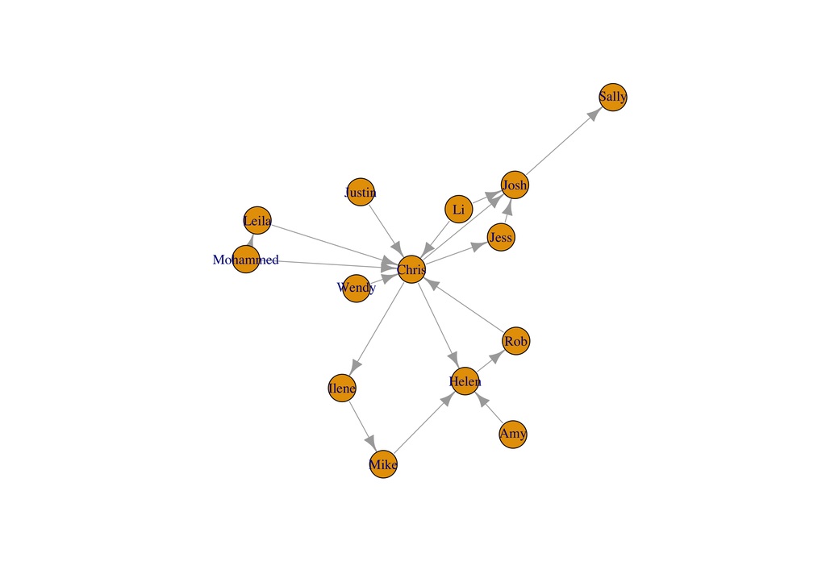

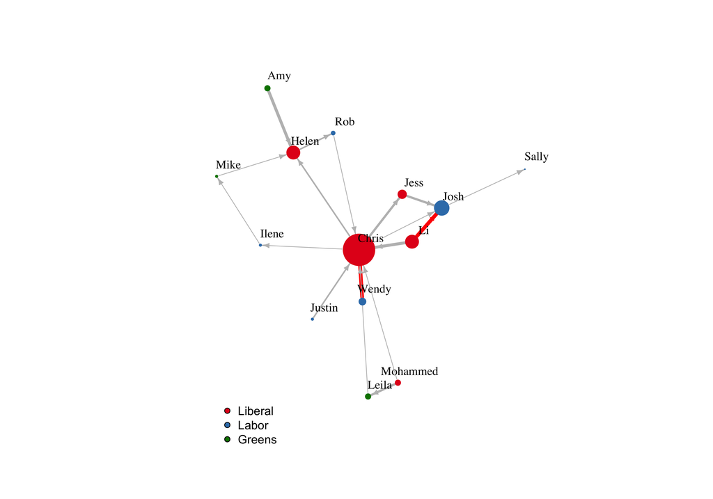

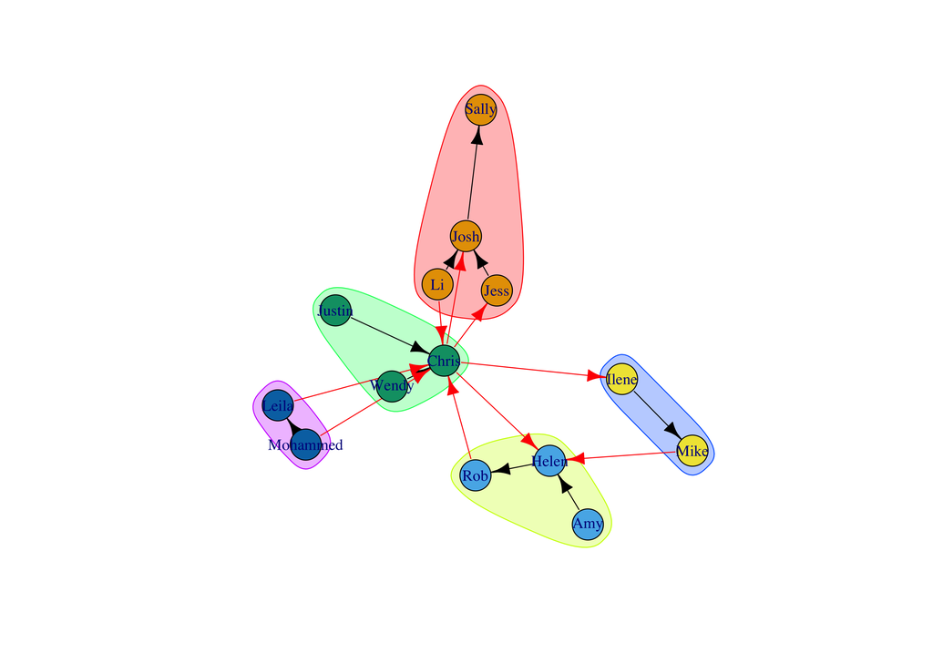

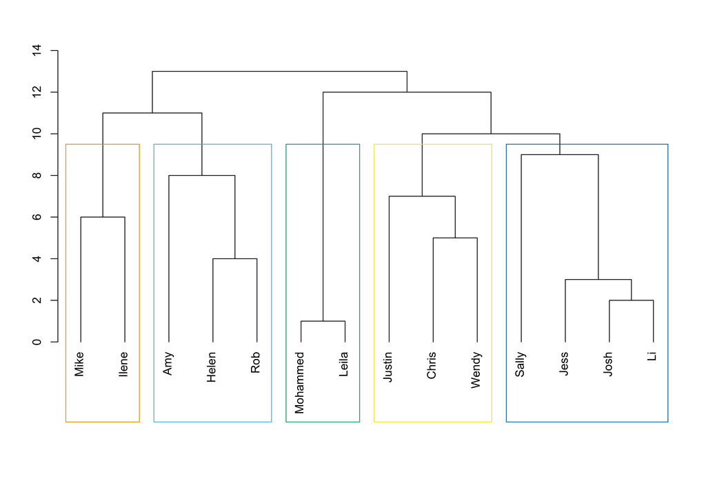

### Additional resources:

- DataCamp is a great resource for all things statistical programming and has a dedicated course on social network analysis in R found [here](https://www.datacamp.com/courses/network-analysis-in-r).
- [Free](http://www.faculty.ucr.edu/~hanneman/nettext/) online book on SNA.
- [igraph](https://igraph.org/r/) package documentation.
- [Social Netowrks](https://www.journals.elsevier.com/social-networks) is a leading journal dedicated to multidisciplinary research on social networks
- [Gephi](https://gephi.org/) is a free web-based software that allows you to create awesome social network graphs
- Yang, Song, Franziska Keller, and Lu Zheng. 2016. Social Network Analysis: Methods and Examples. Sage Publications.
- Freeman, Linton C. 2004. The Development of Social Network Analysis: A Study in the Sociology of Science. Vancouver: Empirical Press.
- Borgatti, Stephen P., Ajay Mehra, Daniel J. Brass, and Giuseppe Labianca. 2009. “Network Analysis in the Social Sciences.” Science 323: 892-895.